# 算法训练营Day 20

Author

Siru Wu

Published

February 2, 2026

## [235. 二叉搜索树的最近公共祖先](https://leetcode.cn/problems/lowest-common-ancestor-of-a-binary-search-tree/description/)

> 给定一个二叉搜索树, 找到该树中两个指定节点的最近公共祖先。

> 百度百科中最近公共祖先的定义为：“对于有根树 T 的两个结点 p、q，最近公共祖先表示为一个结点 x，满足 x 是 p、q 的祖先且 x 的深度尽可能大（一个节点也可以是它自己的祖先）。”

> 例如，给定如下二叉搜索树: root = [6,2,8,0,4,7,9,null,null,3,5]

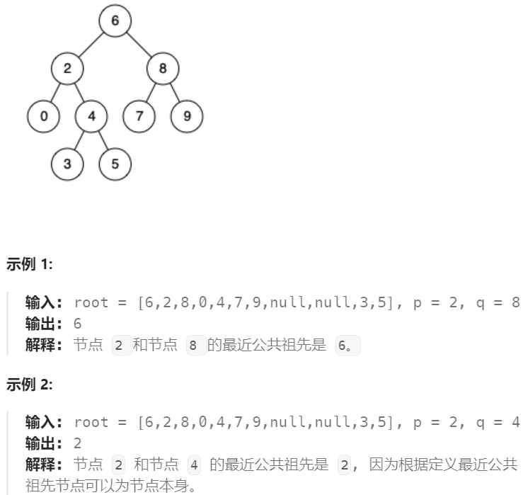

### 递归法

```python
# Definition for a binary tree node.
# class TreeNode:
#     def __init__(self, x):
#         self.val = x
#         self.left = None
#         self.right = None

class Solution:
    def traversal(self, cur, q, p):
        if not cur:
            return cur

        if cur.val > q.val and cur.val > p.val: # 一起在左边
            left = self.traversal(cur.left, p, q)
            if left is not None:
                return left

        if cur.val < q.val and cur.val < p.val: # 一起在右边
            right = self.traversal(cur.right, p, q)
            if right is not None:
                return right

        # 情况 1：p 在左，q 在右
        # 情况 2：q 在左，p 在右
        # 情况 3：cur 本身就是 p 或 q
        return cur

    def lowestCommonAncestor(self, root: 'TreeNode', p: 'TreeNode', q: 'TreeNode') -> 'TreeNode':
        return self.traversal(root, p, q)
```

### 递归法（版本二）精简

```python
class Solution:
    def lowestCommonAncestor(self, root, p, q):
      if root.val > q.val and root.val > p.val:
        return self.lowestCommonAncestor(root.left, p, q)
      elif root.val < q.val and root.val < p.val:
        return self.lowestCommonAncestor(root.right, p, q)
      else:
        return root
```

### 迭代法

```python
class Solution:
    def lowestCommonAncestor(self, root, p, q):
      while root:
        if root.val > p.val and root.val > q.val:
          root = root.left
        elif root.val < p.val and root.val < q.val:
          root = root.right
        else:
          return root
      return None # 迭代版本必须写return None
```

## [701.二叉搜索树中的插入操作](https://leetcode.cn/problems/insert-into-a-binary-search-tree/description/)

> 给定二叉搜索树（BST）的根节点 root 和要插入树中的值 value ，将值插入二叉搜索树。 返回插入后二叉搜索树的根节点。 输入数据 保证 ，新值和原始二叉搜索树中的任意节点值都不同。

> 注意，可能存在多种有效的插入方式，只要树在插入后仍保持为二叉搜索树即可。 你可以返回 任意有效的结果 。

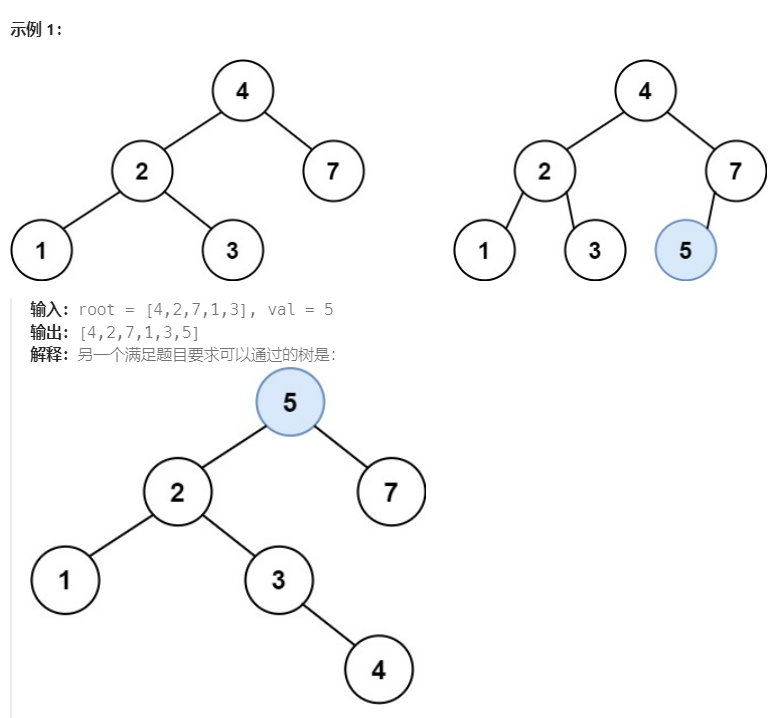

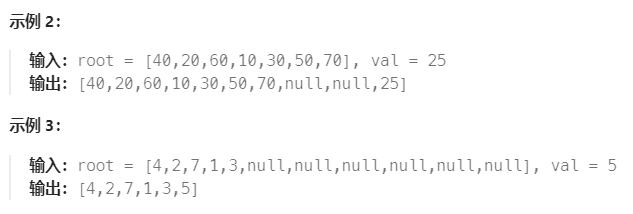

```python
# Definition for a binary tree node.
# class TreeNode:
#     def __init__(self, val=0, left=None, right=None):
#         self.val = val
#         self.left = left
#         self.right = right
class Solution:
    def insertIntoBST(self, root: Optional[TreeNode], val: int) -> Optional[TreeNode]:
        if root is None or root.val == val:
            return TreeNode(val)

        elif root.val > val:
            if root.left is None:
                root.left = TreeNode(val)
            else:
                self.insertIntoBST(root.left, val)

        elif root.val < val:
            if root.right is None:
                root.right = TreeNode(val)
            else:
                self.insertIntoBST(root.right, val)

        return root
```

## [450.删除二叉搜索树中的节点](https://leetcode.cn/problems/delete-node-in-a-bst/description/)

> 给定一个二叉搜索树的根节点 root 和一个值 key，删除二叉搜索树中的 key 对应的节点，并保证二叉搜索树的性质不变。返回二叉搜索树（有可能被更新）的根节点的引用。

> 一般来说，删除节点可分为两个步骤：
> - 首先找到需要删除的节点；
> - 如果找到了，删除它。

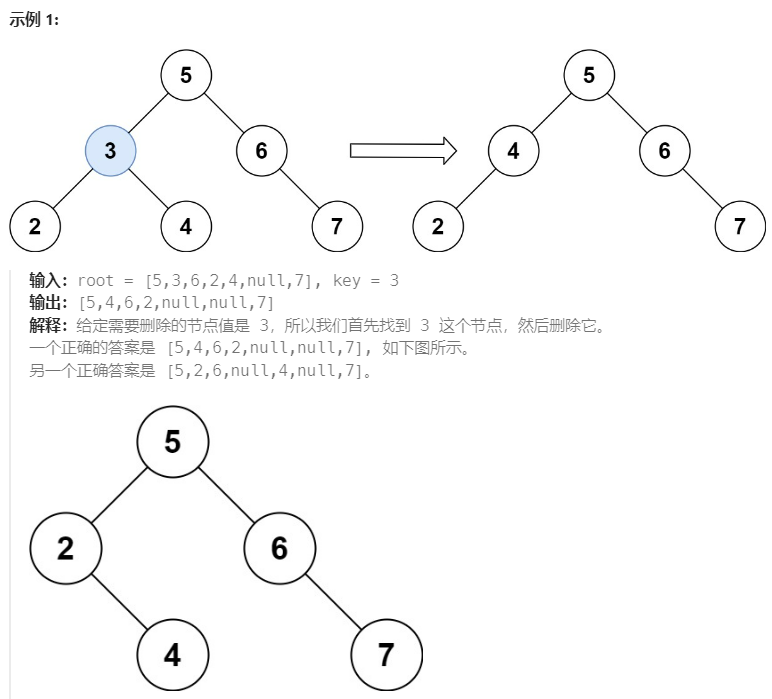

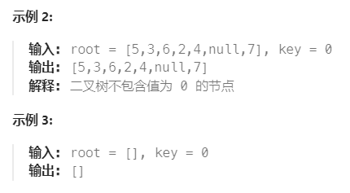

思路：

> 在 BST 中删除 key 用递归先找到它 找到后按节点孩子情况分 3 类处理 最后把更新后的子树一路 return 回去

1️⃣ 先递归找到要删除的节点

1. 如果当前 `root` 是空
   - 说明没找到
   - 直接返回 None
2. 如果 `key < root.val`
   - 根据 BST 规则，只可能在左子树
   - 去左子树递归删除
   - 把返回结果重新接回 `root.left`
3. 如果 `key > root.val`
   - 只可能在右子树
   - 去右子树递归删除
   - 把返回结果重新接回 `root.right`

> 这一阶段只是“定位 key”，不做真正删除

2️⃣ 找到 key 后，按节点情况分类删除

当 `root.val == key`，真正开始删，分三种情况：

1. **没有孩子（叶子节点）**
   - 直接删掉
   - 返回 None
2. **只有一个孩子**
   - 用那个孩子顶替当前节点
   - 返回 `root.left` 或 `root.right`
3. **左右孩子都有**
   - 用右子树整体顶替当前节点
   - 在右子树中找到最小节点
   - 把原来的左子树接到这个最小节点的左边
   - 返回新的根（`root.right`）

> 这一阶段是“真正删除 + 保证 BST 不乱”

3️⃣ 删除完成后，把结果往上返回

1. 每一层递归都会 return 一个“更新后的子树根”
2. 父节点用这个返回值，重新接好左或右子树
3. 最终最外层 return 的，就是删除后的整棵树根

```python
# Definition for a binary tree node.
# class TreeNode:
#     def __init__(self, val=0, left=None, right=None):
#         self.val = val
#         self.left = left
#         self.right = right
class Solution:
    def deleteNode(self, root: Optional[TreeNode], key: int) -> Optional[TreeNode]:
        if root is None:
            return root

        if root.val == key:
            if root.left is None and root.right is None:
                return None
            elif root.left is None:
                return root.right
            elif root.right is None:
                return root.left
            else: # 移除root
                cur = root.right
                while cur.left is not None:
                    cur = cur.left
                cur.left = root.left
                return root.right

        # 还没找到 key，继续往下递归
        if root.val > key: # key 比当前节点小
            root.left = self.deleteNode(root.left, key)
        if root.val < key:
            root.right = self.deleteNode(root.right, key)
        return root
```